# Lab 1

Mia Dawson, GEO200CN, Spring 2016

## Instructions

**1) Carefully read chapter 1 to 6 in http://rspatial.org/intr/**

**2) Read and explore data**

There are two text files with data (loblolly.dat) and (ChickWeightSub.csv).

Write a script (including brief comments) that

1. Reads them into R
2. for both data sets, lists all the variable names
3. for each variable in one of the data sets, use a function to compute the min and a function to compute the mean value
4. now pick one variable from one data set and use functions summary, table, quantile, and boxplot

**Hand in the results as a R Markdown file.** Both the source file and a pdf (amended in lab to html). You can complete the .Rmd file available on smartsite.

## Results

1. Read files into R

```r
datapath = "/users/miadawson/Documents/~UC Davis~/~GEO 200CN/labs/lab 1" #assign directory location to an object called datapath
ChickWeights = read.csv((file.path(datapath, "ChickWeightSub.csv"))) #read provided csv and assign to an object
loblolly = read.delim((file.path(datapath, "loblolly.dat")), sep = " ") #read provided .dat and assign to an object
```

2. for both data sets, list all variable names

```r
colnames(ChickWeights) #list column (variable) names
```

```
## [1] "Weight"  "DayOld"  "ChickID" "DietID"
```

```r
names(loblolly) #list column (variable) names
```

```
## [1] "height" "age"    "Seed"
```

3. for each variable in one of the data sets, use a function to compute the min and a function to compute the mean value

```r
#data set chosen: loblolly
min(loblolly$height) #gives mininum value for height
```

```
## [1] 3.46
```

```r
mean(loblolly$height) #gives mean value for height
```

```
## [1] 32.3644
```

```r
min(loblolly$age) #gives mininum value for age
```

```
## [1] 3
```

```r
mean(loblolly$age)#gives mean value for age
```

```
## [1] 13
```

```r
min(loblolly$Seed) #gives mininum value for seed
```

```
## [1] 301
```

```r
mean(loblolly$Seed) #gives mean value for seed
```

```
## [1] 316.1429
```

4. now pick one variable from one data set and use functions summary, table, quantile, and boxplot

```r
#Data set chosen: ChickWeights, variable chosen: Weight
summary(ChickWeights$Weight) #this function lists min, max, median, mean, 1st and 3rd quantile values
```

```
##    Min. 1st Qu.  Median    Mean 3rd Qu.    Max.
##   39.00   64.75   92.00  106.80  146.00  234.00
```

```r
table(ChickWeights$Weight) #this gives a table of values, showing their frequencies
```

```
##
##  39  41  42  43  72  73  74  77  78  84  86  98 108 123 127 130 137 141
##   2   3   3   1   1   1   1   2   1   2   1   1   1   1   1   1   1   1
## 145 146 148 155 160 168 184 207 214 234
##   1   2   1   1   1   1   1   1   1   1
```

```r
quantile(ChickWeights$Weight) #this gives quantile values. it is basically the same as the summary command but lists values as 0%, 25%, 50%, 75%, 100% instead of their character names
```

```
##     0%    25%    50%    75%   100%
##  39.00  64.75  92.00 146.00 234.00
```

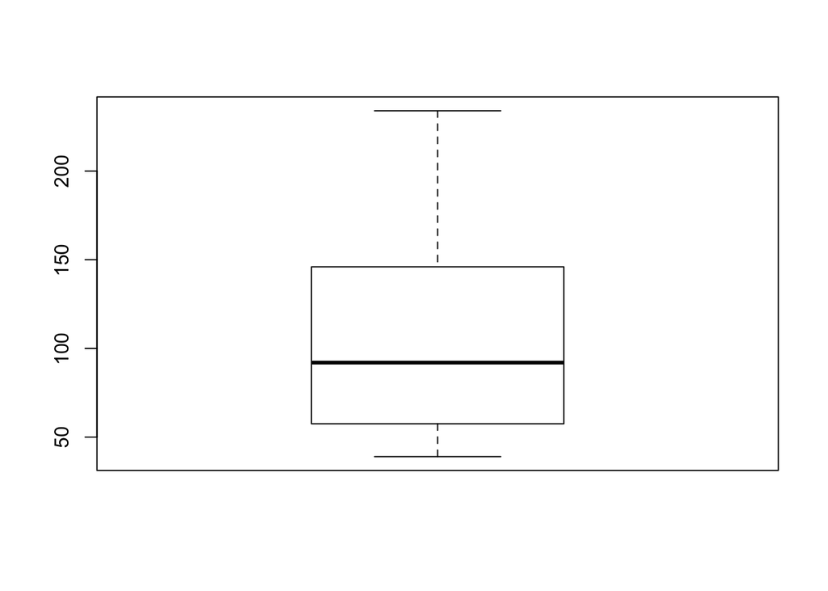

```r
boxplot(ChickWeights$Weight) #this displays the quintle values visually
```